# Accessing Spanish AQ and met data with `saqgetr` and `worldmet`

2019-09-13

# Preparation

To start with, some R packages need to be installed for the following analysis.

```r
packages <- c("tidyverse", "saqgetr", "worldmet", "openair")

# install them from CRAN if you haven't them before
# install.packages(packages)

# load packages
library(tidyverse)
library(saqgetr)
library(worldmet)
library(openair)
```

- `tidyverse` has many useful functions for data manipulation.
- `saqgetr` imports AQ data.
- `worldmet` imports meteorology data.
- `openair` has many useful functions for analysing AQ data.

# Getting Spanish AQ data

We will use the `saqgetr` to access AQ data. This package not only lets you access AQ data in Spain but also most European countries.

```r
get_saq_sites() %>%
  count(country)
```

```
## # A tibble: 42 x 2
##    country                    n
##    <chr>                  <int>
##  1 <NA>                      10
##  2 albania                    7
##  3 andorra                    3
##  4 austria                  284
##  5 belgium                  422
##  6 bosnia_and_herzegovina    16
##  7 bulgaria                  49
##  8 croatia                   24
##  9 cyprus                     9
## 10 czechia                  241
## # ... with 32 more rows
```

The `%>%` (pipe) symbol will be used extensively in the following analysis. It’s a way of saying get the results from `get_saq_sites()` and send it to the `count()` function. The piped result will be used as the first argument of the next function by default. It is equivalent to:

```r
count(x = get_saq_sites(), country)
```

But using the pipe symbol is a more intuitive way to express doing a chain of actions rather than having the initial input nested in a bunch of functions.

Now let’s see what data are available in Spain. We can extract all sites in Spain.

```r
# get Spanish sites
spain_sites <- get_saq_sites() %>%
  filter(country == "spain")

DT::datatable(spain_sites,
              options = list(scrollX = TRUE))
```

|  | site | site_name | latitude | longitude | elevation | country | country_iso_code | site_type | site_area | date_start | date_end | network | eu_code | eoi_code | observation_count | data_source |
| --- | --- | --- | --- | --- | --- | --- | --- | --- | --- | --- | --- | --- | --- | --- | --- | --- |
| 1 | es0001r | SAN PABLO DE LOS MONTES | 39.54694 | -4.35056 | 917 | spain | ES | background | rural | 1997-01-01T00:00:00Z | 2019-08-17T10:00:00Z | NET_ES058A | STA_ES0001R | ES0001R | 349526 | airbase; aqer:e1a; aqer:e2a |
| 2 | es0005r | NOIA | 42.72056 | -8.92361 | 685 | spain | ES | background | rural | 2008-01-01T00:00:00Z | 2019-08-17T10:00:00Z | NET_ES058A | STA_ES0005R | ES0005R | 321930 | airbase; aqer:e1a; aqer:e2a |
| 3 | es0006r | MAHÓN | 39.87528 | 4.31639 | 78 | spain | ES | background | rural | 2008-01-01T00:00:00Z | 2019-08-17T10:00:00Z | NET_ES058A | STA_ES0006R | ES0006R | 175397 | airbase; aqer:e1a; aqer:e2a |
| 4 | es0007r | VÍZNAR | 37.23722 | -3.53417 | 1230 | spain | ES | background | rural | 1997-01-01T00:00:00Z | 2019-08-17T10:00:00Z | NET_ES058A | STA_ES0007R | ES0007R | 702178 | airbase; aqer:e1a; aqer:e2a |
| 5 | es0008r | NIEMBRO | 43.43917 | -4.85 | 134 | spain | ES | background | rural | 1999-01-01T00:00:00Z | 2019-07-08T05:00:00Z | NET_ES058A | STA_ES0008R | ES0008R | 692048 | airbase; aqer:e1a; aqer:e2a |
| 6 | es0009r | CAMPISÁBALOS | 41.27417 | -3.1425 | 1360 | spain | ES | background | rural | 1999-01-01T00:00:00Z | 2019-08-17T10:00:00Z | NET_ES058A | STA_ES0009R | ES0009R | 647784 | airbase; aqer:e1a; aqer:e2a |
| 7 | es0010r | CABO DE CREUS | 42.31917 | 3.31583 | 76 | spain | ES | background | rural | 1999-01-01T00:00:00Z | 2019-08-17T10:00:00Z | NET_ES058A | STA_ES0010R | ES0010R | 685759 | airbase; aqer:e1a; aqer:e2a |
| 8 | es0011r | BARCARROTA | 38.47278 | -6.92361 | 393 | spain | ES | background | rural | 1999-03-03T00:00:00Z | 2019-08-17T10:00:00Z | NET_ES058A | STA_ES0011R | ES0011R | 646854 | airbase; aqer:e1a; aqer:e2a |
| 9 | es0012r | ZARRA | 39.08278 | -1.10111 | 885 | spain | ES | background | rural | 1999-01-01T00:00:00Z | 2019-08-17T10:00:00Z | NET_ES058A | STA_ES0012R | ES0012R | 690434 | airbase; aqer:e1a; aqer:e2a |
| 10 | es0013r | PEÑAUSENDE | 41.23889 | -5.8975 | 985 | spain | ES | background | rural | 2000-08-01T00:00:00Z | 2019-08-17T10:00:00Z | NET_ES058A | STA_ES0013R | ES0013R | 619454 | airbase; aqer:e1a; aqer:e2a |

[output cut: 920 more lines]

A better way to visualise the data available is to plot them on a map. Thanks to the `ricardor` package, this can be done fairly easily.

```r
devtools::install_github("mohowu/ricardor")
```

```r
library(ricardor)

spain_sites %>%
  mutate(date_end = as.character(date_end)) %>% # convert date to character to allow it show up properly on the map
  sp_from_data_frame(type = "point",
                     latitude = "latitude", longitude = "longitude") %>%
  plot_leaflet(popup = c("site", "site_name", "site_type", "date_end"),
               radius = 8, colour = "red", clusterOptions = leaflet::markerClusterOptions())
```

[interactive chart not shown]

How do we know what measurements each site provides? Each site, variable and measuring period combination is called a process. We can get all the processes using `get_saq_processes()`.

```r
processes <- get_saq_processes()
```

For demonstration I have selected two sites in Huelva that are still in operation in 2019, one industrial site and one traffic site. Let’s see what data are availabe at these sites.

```r
processes %>%
  filter(site %in% c("es1328a", "es1340a")) %>%
  DT::datatable(options = list(scrollX = TRUE))
```

|  | process | site | variable | variable_long | period | unit | date_start | date_end | sample | sampling_point | sampling_process | observed_property | group_code | data_source | observation_count |
| --- | --- | --- | --- | --- | --- | --- | --- | --- | --- | --- | --- | --- | --- | --- | --- |
| 1 | 36234 | es1328a | so2 | Sulphur dioxide (air) | day | ug.m-3 | 2012-01-01T00:00:00Z | 2012-12-31T00:00:00Z |  |  |  | 1 | 100 | airbase | 354 |
| 2 | 36235 | es1328a | so2 | Sulphur dioxide (air) | hour | ug.m-3 | 2012-01-01T00:00:00Z | 2012-12-31T22:00:00Z |  |  |  | 1 | 100 | airbase | 8312 |
| 3 | 36236 | es1328a | pm10 | Particulate matter &lt; 10 µm (aerosol) | day | ug.m-3 | 2008-01-01T00:00:00Z | 2012-12-31T00:00:00Z |  |  |  | 5 | 100 | airbase | 1606 |
| 4 | 36237 | es1328a | pm10 | Particulate matter &lt; 10 µm (aerosol) | hour | ug.m-3 | 2008-01-01T00:00:00Z | 2008-12-31T22:00:00Z |  |  |  | 5 | 100 | airbase | 8594 |
| 5 | 36238 | es1328a | no2 | Nitrogen dioxide (air) | day | ug.m-3 | 2007-01-01T00:00:00Z | 2012-12-31T00:00:00Z |  |  |  | 8 | 100 | airbase | 1783 |
| 6 | 36239 | es1328a | no2 | Nitrogen dioxide (air) | hour | ug.m-3 | 2007-01-01T00:00:00Z | 2012-12-31T22:00:00Z |  |  |  | 8 | 100 | airbase | 42200 |
| 7 | 36240 | es1328a | nox | Nitrogen oxides (air) | day | ugNO2.m-3 | 2007-01-01T00:00:00Z | 2012-12-31T00:00:00Z |  |  |  | 9 | 100 | airbase | 1783 |
| 8 | 36241 | es1328a | nox | Nitrogen oxides (air) | hour | ugNO2.m-3 | 2007-01-01T00:00:00Z | 2012-12-31T22:00:00Z |  |  |  | 9 | 100 | airbase | 42202 |
| 9 | 36242 | es1328a | co | Carbon monoxide (air) | day | mg.m-3 | 2007-01-08T00:00:00Z | 2012-12-31T00:00:00Z |  |  |  | 10 | 100 | airbase | 1396 |
| 10 | 36243 | es1328a | co | Carbon monoxide (air) | dymax | mg.m-3 | 2007-01-08T00:00:00Z | 2012-12-31T00:00:00Z |  |  |  | 10 | 100 | airbase | 1398 |

[output cut: 63 more lines]

Now we can download 2019 data for these two sites.

```r
# select two sites in Huelva
es_aq <- get_saq_observations(
  site = c("es1328a", "es1340a"),
  valid_only = TRUE,
  start = 2019,
  end = 2019,
  verbose = TRUE
)

glimpse(es_aq)
```

```
## Observations: 49,449
## Variables: 9
## $ date     <dttm> 2019-01-11 22:00:00, 2019-01-04 00:00:00, 2019-01-04...
## $ date_end <dttm> 2019-01-11 23:00:00, 2019-01-04 01:00:00, 2019-01-04...
## $ site     <chr> "es1328a", "es1328a", "es1328a", "es1328a", "es1328a"...
## $ variable <chr> "so2", "pm10", "pm10", "pm10", "pm10", "pm10", "pm10"...
## $ process  <int> 305875, 305876, 305876, 305876, 305876, 305876, 30587...
## $ summary  <int> 1, 1, 1, 1, 1, 1, 1, 1, 1, 1, 1, 1, 1, 1, 1, 1, 1, 1,...
## $ validity <int> 1, 1, 1, 1, 1, 1, 1, 1, 1, 1, 1, 1, 1, 1, 1, 1, 1, 1,...
## $ unit     <chr> "ug.m-3", "ug.m-3", "ug.m-3", "ug.m-3", "ug.m-3", "ug...
## $ value    <dbl> 0.00, 42.24, 39.60, 34.32, 29.04, 23.76, 22.88, 22.88...
```

The raw data downloaded by `saqgetr` is in long format, i.e. all the pollutant names (`variable`) are all in one column and their values are all in another column called `value`. However sometimes you may want the data in “wide” format, i.e. every pollutant has its own column filled by its values. You can do this using `saq_clean_obersations`.

```r
# reshpae data into wide format, remember put spread = TRUE
es_aq_clean <- saq_clean_observations(es_aq,
                                      summary = "hour",
                                      valid_only = TRUE,
                                      spread = TRUE)

glimpse(es_aq_clean)
```

```
## Observations: 9,186
## Variables: 9
## $ date     <dttm> 2019-01-01 00:00:00, 2019-01-01 00:00:00, 2019-01-01...
## $ date_end <dttm> 2019-01-01 01:00:00, 2019-01-01 01:00:00, 2019-01-01...
## $ site     <chr> "es1328a", "es1340a", "es1328a", "es1340a", "es1328a"...
## $ co       <dbl> 1.063, 1.049, 0.987, 0.868, 0.883, 0.769, 0.823, 0.80...
## $ no       <dbl> 13, 54, 21, 26, 15, 21, 7, 18, 5, 6, 4, 5, 8, 4, 6, 5...
## $ no2      <dbl> 26, 46, 27, 32, 20, 17, 13, 18, 11, 11, 8, 9, 14, 8, ...
## $ nox      <dbl> 45, 127, 58, 72, 43, 48, 23, 45, 18, 19, 15, 16, 25, ...
## $ pm10     <dbl> NA, 179.52, NA, 127.60, NA, 45.76, NA, 55.44, NA, 43....
## $ so2      <dbl> NA, 1, NA, 2, NA, 2, NA, 2, NA, 2, NA, 2, NA, 3, NA, ...
```

A more generic way to reshape data is using `spread` and `gather` functions in the `tidyverse` package. `spread` converts long data to wide format and vice versa for `gather`.

```r
# long to wide
# First we need to keep only the columns of common ids such as date, site.
# columns that are unique to each variable should be removed, such as process

es_aq %>%
  select(date, site, variable, value) %>%
  spread(key = variable, value = value) %>%
  glimpse()
```

```
## Observations: 9,186
## Variables: 8
## $ date <dttm> 2019-01-01 00:00:00, 2019-01-01 00:00:00, 2019-01-01 01:...
## $ site <chr> "es1328a", "es1340a", "es1328a", "es1340a", "es1328a", "e...
## $ co   <dbl> 1.063, 1.049, 0.987, 0.868, 0.883, 0.769, 0.823, 0.801, 0...
## $ no   <dbl> 13, 54, 21, 26, 15, 21, 7, 18, 5, 6, 4, 5, 8, 4, 6, 5, 5,...
## $ no2  <dbl> 26, 46, 27, 32, 20, 17, 13, 18, 11, 11, 8, 9, 14, 8, 13, ...
## $ nox  <dbl> 45, 127, 58, 72, 43, 48, 23, 45, 18, 19, 15, 16, 25, 14, ...
## $ pm10 <dbl> NA, 179.52, NA, 127.60, NA, 45.76, NA, 55.44, NA, 43.12, ...
## $ so2  <dbl> NA, 1, NA, 2, NA, 2, NA, 2, NA, 2, NA, 2, NA, 3, NA, 3, N...
```

Most data downloaded is at hourly interval. We can average the data to longer periods with `timeAverage()` function from `openair` package.

```r
# calculate daily average
es_aq_month <- timeAverage(es_aq_clean,
                           avg.time = "day", type = "site")

head(es_aq_month)
```

```
## # A tibble: 6 x 9
## # Groups:   site [1]
##   site  date                date_end               co    no   no2   nox
##   <fct> <dttm>              <dttm>              <dbl> <dbl> <dbl> <dbl>
## 1 es13~ 2019-01-01 00:00:00 2019-01-01 07:10:54 0.867  8.64  15.4  27.8
## 2 es13~ 2019-01-02 00:00:00 2019-01-02 08:18:27 0.828 23.5   17.3  52.4
## 3 es13~ 2019-01-03 00:00:00 2019-01-03 04:30:00 0.819  5     13.1  20.1
## 4 es13~ 2019-01-04 00:00:00 2019-01-04 12:30:00 0.840 15.5   23.3  46.6
## 5 es13~ 2019-01-05 00:00:00 2019-01-05 12:30:00 0.858 11.2   21.5  37.9
## 6 es13~ 2019-01-06 00:00:00 2019-01-06 12:30:00 0.825  5.5   11.1  19.1
## # ... with 2 more variables: pm10 <dbl>, so2 <dbl>
```

The AQ data frame does not contain infomation on the stations. We can join them from the `spain_sites` data frame.

```r
# join site coordinates with aq data
es_aq_clean <- es_aq_clean %>%
  left_join(spain_sites[c("site", "site_name", "latitude", "longitude")],
            by = "site")

glimpse(es_aq_clean)
```

```
## Observations: 9,186
## Variables: 12
## $ date      <dttm> 2019-01-01 00:00:00, 2019-01-01 00:00:00, 2019-01-0...
## $ date_end  <dttm> 2019-01-01 01:00:00, 2019-01-01 01:00:00, 2019-01-0...
## $ site      <chr> "es1328a", "es1340a", "es1328a", "es1340a", "es1328a...
## $ co        <dbl> 1.063, 1.049, 0.987, 0.868, 0.883, 0.769, 0.823, 0.8...
## $ no        <dbl> 13, 54, 21, 26, 15, 21, 7, 18, 5, 6, 4, 5, 8, 4, 6, ...
## $ no2       <dbl> 26, 46, 27, 32, 20, 17, 13, 18, 11, 11, 8, 9, 14, 8,...
## $ nox       <dbl> 45, 127, 58, 72, 43, 48, 23, 45, 18, 19, 15, 16, 25,...
## $ pm10      <dbl> NA, 179.52, NA, 127.60, NA, 45.76, NA, 55.44, NA, 43...
## $ so2       <dbl> NA, 1, NA, 2, NA, 2, NA, 2, NA, 2, NA, 2, NA, 3, NA,...
## $ site_name <chr> "MARISMAS DEL TITÁN", "POZO DULCE", "MARISMAS DEL TI...
## $ latitude  <dbl> 37.25258, 37.25336, 37.25258, 37.25336, 37.25258, 37...
## $ longitude <dbl> -6.94219, -6.93514, -6.94219, -6.93514, -6.94219, -6...
```

Now let’s have a quick visual summary of the data.

```
##       date1       date2   date_end1   date_end2        site          co
##   "POSIXct"    "POSIXt"   "POSIXct"    "POSIXt" "character"   "numeric"
##          no         no2         nox        pm10         so2   site_name
##   "numeric"   "numeric"   "numeric"   "numeric"   "numeric" "character"
##    latitude   longitude
##   "numeric"   "numeric"
```

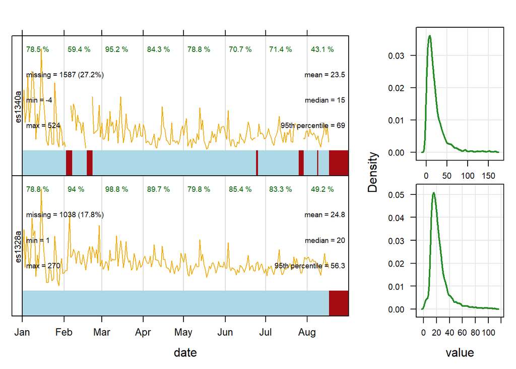

```r
es_aq_clean %>%
  summaryPlot(period = "months", pollutant = "nox", type = "density")
```

The summary plot gives an quick overview of how the pollutant levels compare across different sites. You can find some summary statistics in the timeseries plot. Missing data periods are also marked as red above the timeline.

It’s also possible to summarise all the pollutants at one site.

```
##       date1       date2   date_end1   date_end2        site          co
##   "POSIXct"    "POSIXt"   "POSIXct"    "POSIXt" "character"   "numeric"
##          no         no2         nox        pm10         so2   site_name
##   "numeric"   "numeric"   "numeric"   "numeric"   "numeric" "character"
```

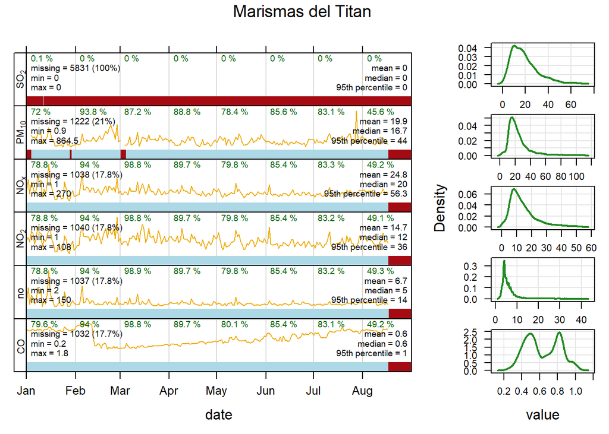

```r
es_aq_clean %>%
  filter(site == "es1328a") %>%
  select(-latitude, -longitude) %>%
  summaryPlot(period = "months", type = "density", main = "Marismas del Titan")
```

# Get met data

`worldmet` package is used to get meteorology data. `getMeta` function gets a table of met stations that are closest to the AQ monitoring sites based on the latitude and longitude supplied.

```r
# search the closest met station
getMeta(lat = es_aq_clean$latitude[1],
        lon = es_aq_clean$longitude[1])
```

```
## # A tibble: 10 x 15
##    USAF  WBAN  STATION CTRY  ST    CALL  latitude longitude `ELEV(M)`
##    <chr> <chr> <chr>   <chr> <chr> <chr>    <dbl>     <dbl>     <dbl>
##  1 0838~ 99999 HUELVA  SP    <NA>  <NA>      37.3     -6.92      20
##  2 0839~ 99999 SEVILL~ SP    <NA>  LEEC      37.3     -6          5
##  3 0844~ 13025 ROTA N~ SP    <NA>  LERT      36.6     -6.35      25.6
##  4 0855~ 99999 FARO    PO    <NA>  LPFR      37.0     -7.97       7.3
##  5 0839~ 99999 SEVILLA SP    <NA>  LEZL      37.4     -5.89      33.8
##  6 0845~ 99999 JEREZ   SP    <NA>  LEJR      36.7     -6.06      28.3
##  7 0845~ 99999 CADIZ ~ SP    <NA>  <NA>      36.5     -6.25       9
##  8 0845~ 99999 SAN FE~ SP    <NA>  <NA>      36.5     -6.2       30
##  9 0839~ 99999 MORON ~ SP    <NA>  LEMO      37.2     -5.62      86.9
## 10 0856~ 99999 BEJA/B~ PO    <NA>  <NA>      38.1     -7.92     203
## # ... with 6 more variables: BEGIN <date>, END <date>, code <chr>,
## #   longR <dbl>, latR <dbl>, dist <dbl>
```

```r
# import met data
met <- importNOAA(code = "083830-99999", year = 2019)

head(met)
```

```
## # A tibble: 6 x 23
##   date                usaf  wban  code  station   lat   lon  elev    wd
##   <dttm>              <chr> <chr> <chr> <chr>   <dbl> <dbl> <dbl> <dbl>
## 1 2019-01-01 00:00:00 0838~ 99999 0838~ HUELVA   37.3 -6.92    20  30.0
## 2 2019-01-01 01:00:00 0838~ 99999 0838~ HUELVA   37.3 -6.92    20  20
## 3 2019-01-01 02:00:00 0838~ 99999 0838~ HUELVA   37.3 -6.92    20  20
## 4 2019-01-01 03:00:00 0838~ 99999 0838~ HUELVA   37.3 -6.92    20  20
## 5 2019-01-01 04:00:00 0838~ 99999 0838~ HUELVA   37.3 -6.92    20  20
## 6 2019-01-01 05:00:00 0838~ 99999 0838~ HUELVA   37.3 -6.92    20  30.0
## # ... with 14 more variables: ws <dbl>, ceil_hgt <dbl>, visibility <dbl>,
## #   air_temp <dbl>, dew_point <dbl>, atmos_pres <dbl>, RH <dbl>,
## #   cl_1 <dbl>, cl_1_height <dbl>, cl_2 <dbl>, cl_2_height <dbl>,
## #   cl_3 <dbl>, cl_3_height <dbl>, cl <dbl>
```

Now we can join the met data with AQ data.

```r
# joint met data with aq data
es_aq_clean <- es_aq_clean %>%
  left_join(met[c("date", "wd", "ws", "air_temp")], by = "date")
```

Let’s plot a wind rose plot to see the wind profile at the stations.It seems like there is a good proportion of wind coming from all directions except Southeast.

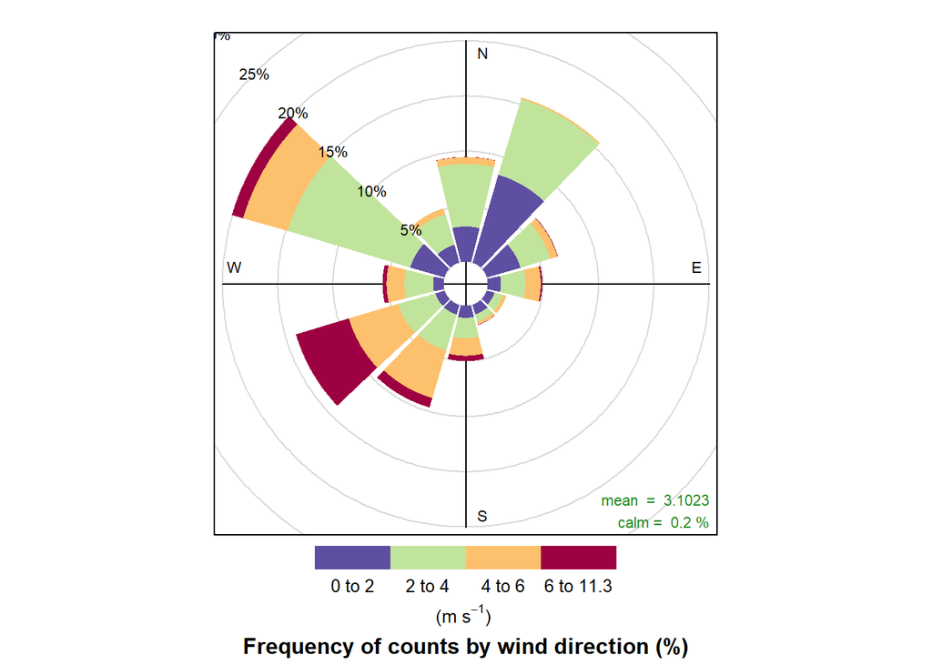

```r
es_aq_clean %>%
  filter(site == "es1340a") %>%
  windRose(paddle = FALSE)
```

We can also replace the wind speed data in the plot above with other variables, such as pollutant concentration. This lets us see the relationship between wind direction and pollutant concentration.

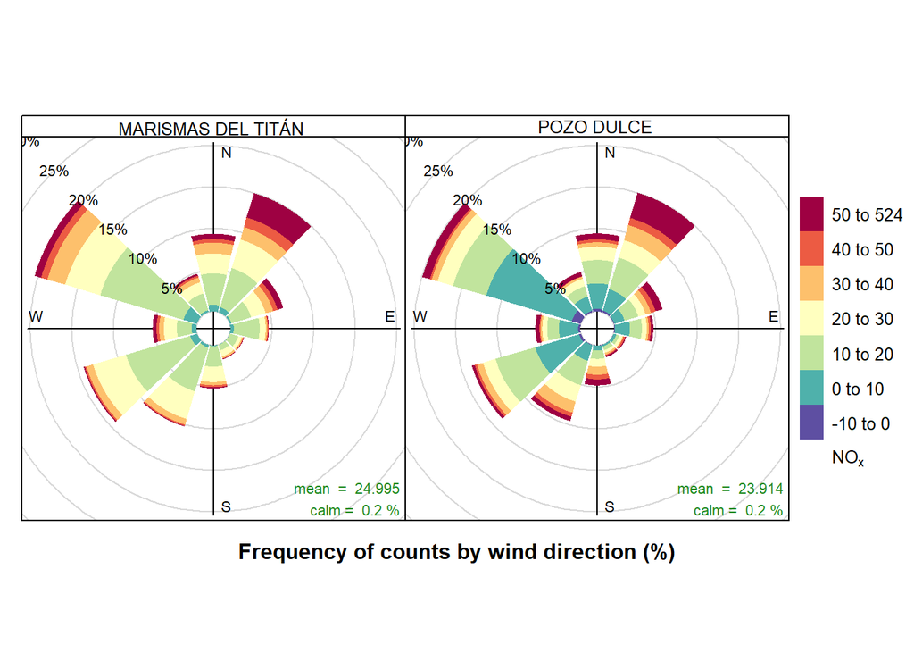

```r
es_aq_clean %>%
  pollutionRose(pullutatnt ="nox", type = "site_name")
```

A even better way to visualise the relationship between pollutant concentration and wind conditions is using `polarPlot()` function. This kind of plot is very powerful because it encapsulate 3 dimensions, i.e. pullutant concentration, wind speed and direction.

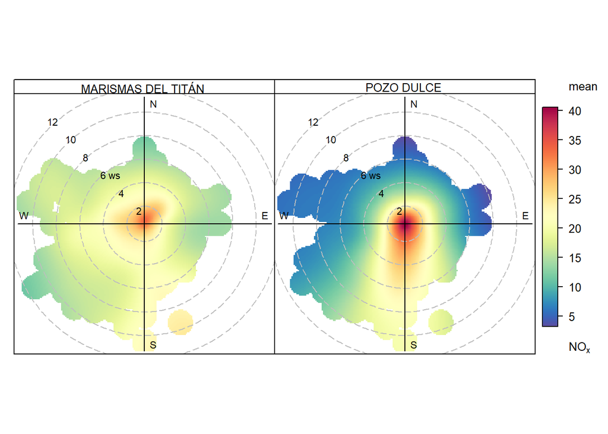

```r
es_aq_clean %>%
  polarPlot(pollutant = "nox", type = "site_name")
```

This plot clearly shows the direction of the pollution source with respect to the station. Pozo Dulce is at the North of a roundabout, hence the high pollution plume predominately coming from the South. Marismas Del Titan is classified as an industrial site. However judging by the polar plot it looks more like a background site without any dominant source from any direction.